# Green Market Game: Calibration Pilot

Can a marketing game serve as a DV for synthetic contact experiments?

```r
library(tidyverse)
library(arrow)
library(patchwork)
library(lme4)
library(lmerTest)
library(broom.mixed)

# Remap "difficulty" to neutral version labels (the manipulation was flawed)
VERSION_LABELS <- c(easy = "Version A", medium = "Version B", hard = "Version C")
VERSION_COLORS <- c(easy = "#22c55e", medium = "#f59e0b", hard = "#ef4444")

MARKET_COLORS <- c(
  harlan = "#dc2626", williamson = "#f97316",
  burlington = "#3b82f6", middlesex = "#1d4ed8"
)
MARKET_LABELS <- c(
  harlan = "Harlan, KY (78% R)", williamson = "Williamson, TN (72% R)",
  burlington = "Burlington, VT (68% D)", middlesex = "Middlesex, MA (72% D)"
)
PARTY_COLORS <- c(
  "Strong Democrat" = "#1d4ed8", "Lean Democrat" = "#60a5fa",
  "Independent" = "#9ca3af",
  "Lean Republican" = "#f87171", "Strong Republican" = "#dc2626"
)
PARTY_LEAN_COLORS <- c(Democrat = "#2563eb", Independent = "#9ca3af", Republican = "#dc2626")

is_running_in_quarto <- function() {
  Sys.getenv("QUARTO_DOCUMENT_PATH") != ""
}

if (is_running_in_quarto()) {
  d <- read_parquet("clean_data.parquet")
  rounds <- read_parquet("round_data.parquet")
} else {
  d <- read_parquet("pilots/green-market-game/clean_data.parquet")
  rounds <- read_parquet("pilots/green-market-game/round_data.parquet")
}

# Add version labels
d <- d |> mutate(version = VERSION_LABELS[as.character(difficulty)])
rounds <- rounds |> mutate(version = VERSION_LABELS[as.character(difficulty)])
```

## Executive Summary

# The Game Produces Robust Learning

## How revenue is generated

Participants played 8 rounds of a marketing allocation game, distributing a $100k budget across 4 U.S. markets to sell eco-friendly products. Each round, revenue for a given market is computed as:

$$\text{Revenue} = \underbrace{\text{receptive population}}_{\text{market size} \times \text{weighted receptivity}} \times \underbrace{f(\text{spend})}_{\text{diminishing returns}} \times \underbrace{e^{-K \times \text{competition}}}_{\text{competition discount}} \times \$7 + \varepsilon$$

where:

- **Receptive population** = market size $\times$ (% Republican $\times$ 0.65 + % Democrat $\times$ 0.75). Both parties are somewhat receptive to eco products, but Democrats slightly more so (75% vs 65%).
- **Diminishing returns**: spending follows a log-saturation curve — the first dollars in a market generate more than the last.
- **Competition discount**: $e^{-K \times c}$, where $c$ is the market’s competition level. Low-competition markets (Harlan: $c$ = 0.20) retain most of the spend; high-competition markets (Middlesex: $c$ = 0.85) lose most of it.
- **Noise** ($\varepsilon$): Gaussian noise proportional to mean revenue.

The key insight: even though D-leaning markets have slightly higher eco-receptivity, their high competition levels eat into returns. R-leaning markets, with low competition, generate more revenue per dollar. The optimal strategy is to overweight R-leaning markets — the opposite of what most participants’ political priors suggest.

```r
tibble(
  Market = c("Harlan, KY", "Williamson, TN", "Burlington, VT", "Middlesex, MA"),
  `Partisan lean` = c("78% R", "72% R", "68% D", "72% D"),
  `Market size` = c("50k", "75k", "45k", "65k"),
  Competition = c("Low (0.20)", "Moderate (0.35)", "Moderate (0.45)", "Very high (0.85)"),
  `Net effect` = c("High ROI", "High ROI", "Moderate ROI", "Low ROI")
) |> knitr::kable(caption = "Market characteristics: competition, not receptivity, drives returns")
```

Market characteristics: competition, not receptivity, drives returns

| Market | Partisan lean | Market size | Competition | Net effect |
| --- | --- | --- | --- | --- |
| Harlan, KY | 78% R | 50k | Low (0.20) | High ROI |
| Williamson, TN | 72% R | 75k | Moderate (0.35) | High ROI |
| Burlington, VT | 68% D | 45k | Moderate (0.45) | Moderate ROI |
| Middlesex, MA | 72% D | 65k | Very high (0.85) | Low ROI |

## Pre-post allocation shift

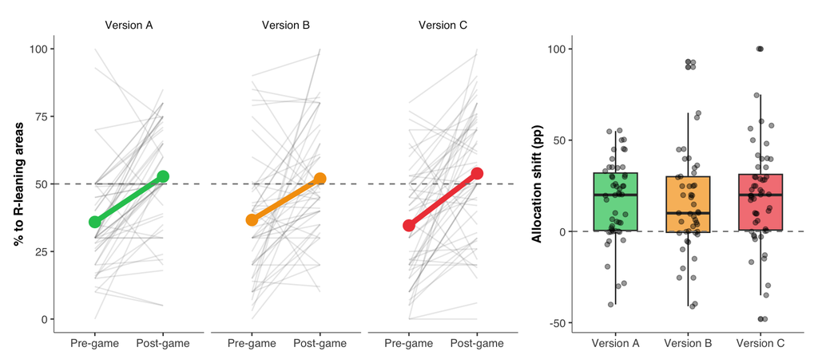

Figure 1: Pre- vs. post-game stated allocation to R-leaning areas

```r
p1 <- d |>
  pivot_longer(cols = c(pre_pct_R, post_pct_R),
               names_to = "time", values_to = "pct_R") |>
  mutate(time = factor(time,
    levels = c("pre_pct_R", "post_pct_R"),
    labels = c("Pre-game", "Post-game")
  )) |>
  ggplot(aes(x = time, y = pct_R, group = id)) +
  geom_line(alpha = 0.15, color = "grey40") +
  stat_summary(aes(group = version, color = version),
    fun = mean, geom = "line", linewidth = 2
  ) +
  stat_summary(aes(group = version, color = version),
    fun = mean, geom = "point", size = 4
  ) +
  geom_hline(yintercept = 50, linetype = "dashed", color = "grey50") +
  facet_wrap(~version) +
  scale_color_manual(values = setNames(VERSION_COLORS, VERSION_LABELS), guide = "none") +
  scale_y_continuous(limits = c(0, 100)) +
  labs(x = NULL, y = "% to R-leaning areas")

p2 <- d |>
  ggplot(aes(x = version, y = alloc_shift, fill = version)) +
  geom_boxplot(alpha = 0.7, width = 0.6) +
  geom_jitter(width = 0.15, alpha = 0.4, size = 1.5) +
  geom_hline(yintercept = 0, linetype = "dashed", color = "grey50") +
  scale_fill_manual(values = setNames(VERSION_COLORS, VERSION_LABELS), guide = "none") +
  labs(x = NULL, y = "Allocation shift (pp)")

p1 + p2 + plot_layout(widths = c(2, 1))
```

```r
alloc_tests <- d |>
  group_by(version) |>
  summarize(
    n = n(),
    mean_pre = mean(pre_pct_R, na.rm = TRUE),
    mean_post = mean(post_pct_R, na.rm = TRUE),
    mean_shift = mean(alloc_shift, na.rm = TRUE),
    sd_shift = sd(alloc_shift, na.rm = TRUE),
    t_stat = t.test(alloc_shift)$statistic,
    p_value = t.test(alloc_shift)$p.value,
    d = mean(alloc_shift, na.rm = TRUE) / sd(alloc_shift, na.rm = TRUE),
    .groups = "drop"
  )

alloc_tests |>
  mutate(across(where(is.numeric), \(x) round(x, 3))) |>
  knitr::kable(caption = "Allocation shift: one-sample t-test (shift ≠ 0)")
```

Allocation shift: one-sample t-test (shift ≠ 0)

| version | n | mean_pre | mean_post | mean_shift | sd_shift | t_stat | p_value | d |
| --- | --- | --- | --- | --- | --- | --- | --- | --- |
| Version A | 51 | 35.902 | 52.745 | 16.843 | 21.911 | 5.490 | 0.000 | 0.769 |
| Version B | 47 | 36.660 | 51.936 | 15.277 | 28.226 | 3.710 | 0.001 | 0.541 |
| Version C | 52 | 34.596 | 53.865 | 19.269 | 26.757 | 5.193 | 0.000 | 0.720 |

Pooled across versions, participants shifted their allocations by 17.2 pp toward R-leaning markets (*t*(149) = 8.23, *p* < .001, *d* = 0.67). All three versions produced significant shifts.

## Belief revision

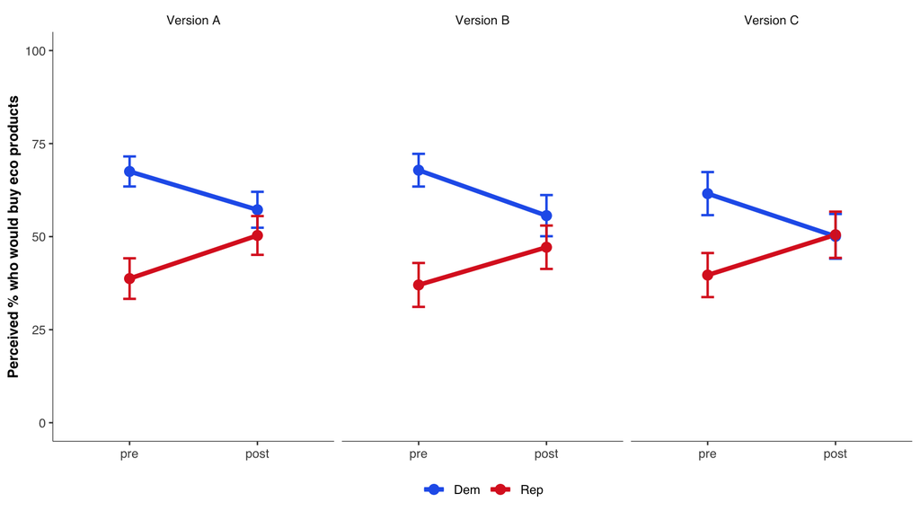

Figure 2: Pre- vs. post-game perceived eco-receptivity for Democrats and Republicans

```r
d |>
  select(id, version,
    `Dem (pre)` = pre_belief_dem, `Dem (post)` = post_belief_dem,
    `Rep (pre)` = pre_belief_rep, `Rep (post)` = post_belief_rep
  ) |>
  pivot_longer(-c(id, version), names_to = "measure", values_to = "pct") |>
  separate(measure, into = c("party", "time"), sep = " \\(") |>
  mutate(time = str_remove(time, "\\)"),
         time = factor(time, levels = c("pre", "post"))) |>
  group_by(version, party, time) |>
  summarize(mean_pct = mean(pct, na.rm = TRUE),
            se = sd(pct, na.rm = TRUE) / sqrt(n()),
            .groups = "drop") |>
  ggplot(aes(x = time, y = mean_pct, color = party, group = party)) +
  geom_line(linewidth = 1.5) +
  geom_point(size = 3) +
  geom_errorbar(aes(ymin = mean_pct - 1.96 * se, ymax = mean_pct + 1.96 * se),
                width = 0.1, linewidth = 0.8) +
  facet_wrap(~version) +
  scale_color_manual(values = c(Dem = "#2563eb", Rep = "#dc2626")) +
  scale_y_continuous(limits = c(0, 100)) +
  labs(x = NULL, y = "Perceived % who would buy eco products", color = NULL)
```

```r
gap_tests <- d |>
  group_by(version) |>
  summarize(
    `Pre gap (D-R)` = mean(pre_belief_gap, na.rm = TRUE),
    `Post gap (D-R)` = mean(post_belief_gap, na.rm = TRUE),
    `Gap change` = mean(gap_change, na.rm = TRUE),
    t = t.test(gap_change)$statistic,
    p = t.test(gap_change)$p.value,
    d = mean(gap_change, na.rm = TRUE) / sd(gap_change, na.rm = TRUE),
    .groups = "drop"
  )

gap_tests |>
  mutate(across(where(is.numeric), \(x) round(x, 2))) |>
  knitr::kable(caption = "Perceived D-R receptivity gap: does it shrink?")
```

Perceived D-R receptivity gap: does it shrink?

| version | Pre gap (D-R) | Post gap (D-R) | Gap change | t | p | d |
| --- | --- | --- | --- | --- | --- | --- |
| Version A | 28.78 | 6.90 | -21.88 | -5.57 | 0 | -0.78 |
| Version B | 30.83 | 8.49 | -22.34 | -3.88 | 0 | -0.57 |
| Version C | 21.88 | -0.42 | -22.31 | -4.27 | 0 | -0.59 |

The perceived D-R gap shrank by 22.2 pp (*t*(149) = -7.74, *p* < .001, *d* = -0.63), driven by upward revision of Republican eco-receptivity (+10.9 pp) and comparable downward revision of Democrat eco-receptivity (-11.3 pp).

```r
es_tab <- d |>
  summarize(
    `Allocation shift` = mean(alloc_shift, na.rm = TRUE) / sd(alloc_shift, na.rm = TRUE),
    `Rep belief shift` = mean(belief_shift_rep, na.rm = TRUE) / sd(belief_shift_rep, na.rm = TRUE),
    `Dem belief shift` = mean(belief_shift_dem, na.rm = TRUE) / sd(belief_shift_dem, na.rm = TRUE),
    `D-R gap shrinkage` = mean(gap_change, na.rm = TRUE) / sd(gap_change, na.rm = TRUE),
  ) |>
  pivot_longer(everything(), names_to = "Measure", values_to = "Cohen's d") |>
  mutate(`Cohen's d` = round(`Cohen's d`, 2))

es_tab |> knitr::kable(caption = "Effect sizes (pooled across versions)")
```

Effect sizes (pooled across versions)

| Measure | Cohen’s d |
| --- | --- |
| Allocation shift | 0.67 |
| Rep belief shift | 0.50 |
| Dem belief shift | -0.63 |
| D-R gap shrinkage | -0.63 |

# Bayesian Learning Model

## The model

Participants enter the game with a prior belief about the optimal share to allocate to R-leaning markets. Each round, revenue feedback provides a noisy signal about the true optimal allocation. Under a standard Normal-Normal Bayesian updating framework (Erdem & Keane, 1996; DeGroot, 1970), the posterior allocation at round $t$ follows:

$$\text{pct\_R}_t = \theta^* + (m_0 - \theta^*) \cdot \frac{\tau}{\tau + t}$$

where:

- $m_0$ = **prior** — the agent’s initial belief about optimal R-allocation (before any gameplay)
- $\theta^*$ = **asymptote** — what the agent converges to with infinite experience
- $\tau$ = **learning speed** — the number of rounds needed to halve the weight on the prior (lower $\tau$ = faster learning). Formally, $\tau = \sigma_s^2 / \sigma_0^2$, the ratio of signal noise to prior variance

The weight on the prior at round $t$ is $w_t = \tau / (\tau + t)$, which decays hyperbolically — fast at first, then more slowly.

## Model fit

```r
# Fit to group means by party
fit_bayes_curve <- function(data) {
  gm <- data |> group_by(round) |> summarize(pct_R = mean(pct_R, na.rm = TRUE), .groups = "drop")
  fit <- tryCatch(
    nls(pct_R ~ theta + (m0 - theta) * tau / (tau + round),
        data = gm, start = list(m0 = gm$pct_R[1] - 5, theta = tail(gm$pct_R, 1) + 5, tau = 1.5),
        control = nls.control(maxiter = 500)),
    error = function(e) NULL
  )
  if (!is.null(fit)) return(fit)
  # Grid search fallback
  best_rss <- Inf; best_p <- NULL
  for (m0 in seq(gm$pct_R[1] - 40, gm$pct_R[1] + 5, by = 2.5)) {
    for (theta in seq(tail(gm$pct_R, 1) - 10, tail(gm$pct_R, 1) + 15, by = 2)) {
      for (tau in seq(0.05, 5, by = 0.05)) {
        pred <- theta + (m0 - theta) * tau / (tau + gm$round)
        rss <- sum((gm$pct_R - pred)^2)
        if (rss < best_rss) { best_rss <- rss; best_p <- c(m0 = m0, theta = theta, tau = tau) }
      }
    }
  }
  tryCatch(
    nls(pct_R ~ theta + (m0 - theta) * tau / (tau + round), data = gm,
        start = as.list(best_p), control = nls.control(maxiter = 500)),
    error = function(e) structure(list(coefs = best_p, rss = best_rss, gm = gm), class = "grid_fit")
  )
}
coef.grid_fit <- function(x, ...) x$coefs
residuals.grid_fit <- function(x, ...) {
  p <- x$coefs; x$gm$pct_R - (p["theta"] + (p["m0"] - p["theta"]) * p["tau"] / (p["tau"] + x$gm$round))
}

bayes_party <- map_dfr(c("Democrat", "Independent", "Republican"), function(pl) {
  fit <- fit_bayes_curve(rounds |> filter(party_lean == pl))
  cc <- coef(fit)
  gm <- rounds |> filter(party_lean == pl) |> group_by(round) |>
    summarize(pct_R = mean(pct_R, na.rm = TRUE), .groups = "drop")
  rss <- sum(residuals(fit)^2)
  r2 <- 1 - rss / sum((gm$pct_R - mean(gm$pct_R))^2)
  tibble(party_lean = pl, m0 = cc["m0"], theta = cc["theta"], tau = cc["tau"], r2 = r2)
})
```

```r
bayes_party |>
  transmute(Group = party_lean, `Prior (m₀)` = m0, `Asymptote (θ*)` = theta,
            `Learning speed (τ)` = tau, `R²` = r2) |>
  mutate(across(where(is.numeric), \(x) round(x, 2))) |>
  knitr::kable(caption = "Bayesian learning model parameters by party (fit to group means)")
```

Bayesian learning model parameters by party (fit to group means)

| Group | Prior (m₀) | Asymptote (θ*) | Learning speed (τ) | R² |
| --- | --- | --- | --- | --- |
| Democrat | -113.07 | 69.21 | 0.25 | 0.99 |
| Independent | -10.69 | 68.76 | 0.70 | 0.98 |
| Republican | 0.70 | 69.98 | 0.60 | 0.86 |

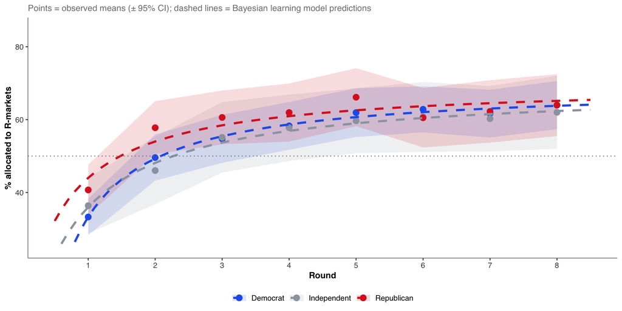

Figure 3: Bayesian learning model: observed vs. predicted allocation curves by party

```r
pred_grid <- expand_grid(
  round = seq(0.5, 8.5, by = 0.1),
  party_lean = c("Democrat", "Independent", "Republican")
) |>
  left_join(bayes_party |> select(party_lean, m0, theta, tau), by = "party_lean") |>
  mutate(predicted = theta + (m0 - theta) * tau / (tau + round))

obs_party <- rounds |>
  filter(!is.na(party_lean)) |>
  group_by(party_lean, round) |>
  summarize(
    mean_pct_R = mean(pct_R, na.rm = TRUE),
    se = sd(pct_R, na.rm = TRUE) / sqrt(n()),
    .groups = "drop"
  )

ggplot() +
  geom_ribbon(data = obs_party,
              aes(x = round, ymin = mean_pct_R - 1.96 * se, ymax = mean_pct_R + 1.96 * se,
                  fill = party_lean), alpha = 0.15) +
  geom_point(data = obs_party, aes(x = round, y = mean_pct_R, color = party_lean), size = 3) +
  geom_line(data = pred_grid, aes(x = round, y = predicted, color = party_lean),
            linewidth = 1.2, linetype = "dashed") +
  geom_hline(yintercept = 50, linetype = "dotted", color = "grey50") +
  scale_color_manual(values = PARTY_LEAN_COLORS) +
  scale_fill_manual(values = PARTY_LEAN_COLORS) +
  scale_x_continuous(breaks = 1:8) +
  scale_y_continuous(limits = c(25, 85)) +
  labs(x = "Round", y = "% allocated to R-markets",
       color = NULL, fill = NULL,
       subtitle = "Points = observed means (± 95% CI); dashed lines = Bayesian learning model predictions")
```

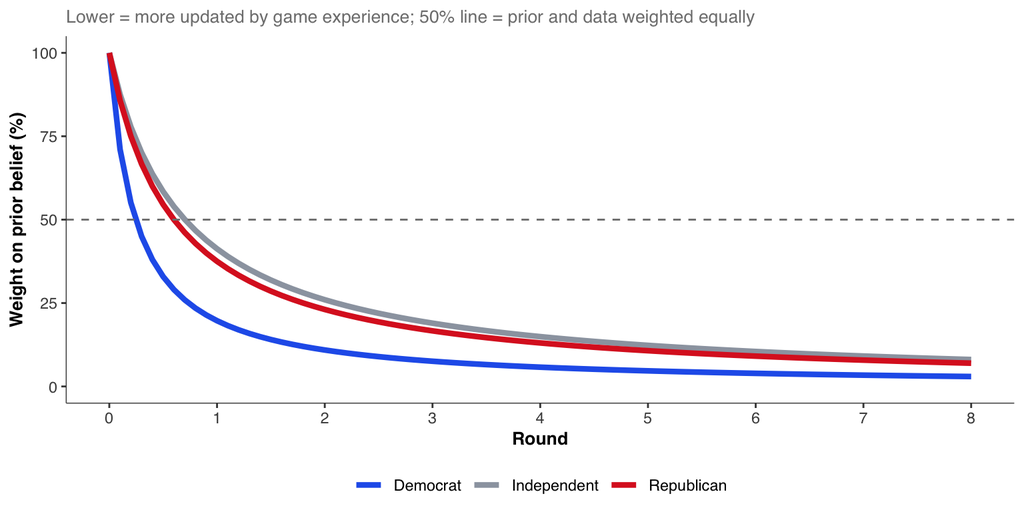

Figure 4: Decay of prior weight across rounds: how quickly do participants update?

```r
weight_grid <- expand_grid(
  round = seq(0, 8, by = 0.1),
  party_lean = c("Democrat", "Independent", "Republican")
) |>
  left_join(bayes_party |> select(party_lean, tau), by = "party_lean") |>
  mutate(prior_weight = tau / (tau + round))

ggplot(weight_grid, aes(x = round, y = prior_weight * 100, color = party_lean)) +
  geom_line(linewidth = 1.5) +
  geom_hline(yintercept = 50, linetype = "dashed", color = "grey50") +
  scale_color_manual(values = PARTY_LEAN_COLORS) +
  scale_x_continuous(breaks = 0:8) +
  scale_y_continuous(limits = c(0, 100)) +
  labs(x = "Round", y = "Weight on prior belief (%)",
       color = NULL,
       subtitle = "Lower = more updated by game experience; 50% line = prior and data weighted equally")
```

# Partisanship: Different Starting Points, Same Destination

## Revenue efficiency by party

```r
# Compute per-version optimal single-round revenue from game parameters
game_towns <- tibble(
  town = c("harlan", "williamson", "burlington", "middlesex"),
  rS = c(0.78, 0.72, 0.32, 0.28),
  dS = c(0.22, 0.28, 0.68, 0.72),
  mkt = c(50000, 75000, 45000, 65000),
  comp = c(0.20, 0.35, 0.45, 0.85)
)

compute_optimal_rev <- function(K) {
  alloc <- rep(0, 4)
  for (i in 1:100) {
    gains <- map_dbl(1:4, function(j) {
      receptive <- game_towns$mkt[j] * (game_towns$rS[j] * 0.65 + game_towns$dS[j] * 0.75)
      old_frac <- log1p(alloc[j] / 10000) / log1p(10)
      new_frac <- log1p((alloc[j] + 1000) / 10000) / log1p(10)
      (new_frac - old_frac) * receptive * exp(-K * game_towns$comp[j]) * 7
    })
    alloc[which.max(gains)] <- alloc[which.max(gains)] + 1000
  }
  sum(map_dbl(1:4, function(j) {
    game_towns$mkt[j] * (game_towns$rS[j] * 0.65 + game_towns$dS[j] * 0.75) *
      log1p(alloc[j] / 10000) / log1p(10) * exp(-K * game_towns$comp[j]) * 7
  }))
}

opt_by_version <- tibble(
  difficulty = factor(c("easy", "medium", "hard"), levels = c("easy", "medium", "hard")),
  optimal_rev = map_dbl(c(1.5, 2, 2.5), compute_optimal_rev)
)

rounds <- rounds |>
  left_join(opt_by_version, by = "difficulty") |>
  mutate(pct_optimal_round = total_rev / optimal_rev * 100)
```

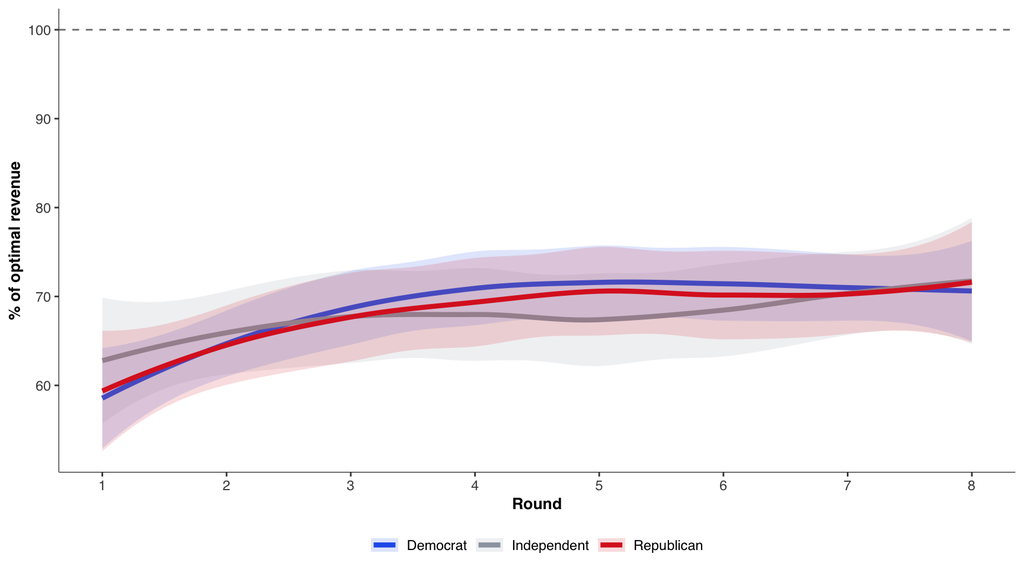

Figure 5: Revenue efficiency (% of version-specific optimal) by party across rounds

```r
rounds |>
  filter(!is.na(party_lean)) |>
  ggplot(aes(x = round, y = pct_optimal_round, color = party_lean, fill = party_lean)) +
  geom_smooth(method = "loess", span = 0.75, alpha = 0.15, linewidth = 1.5) +
  geom_hline(yintercept = 100, linetype = "dashed", color = "grey50") +
  scale_color_manual(values = PARTY_LEAN_COLORS) +
  scale_fill_manual(values = PARTY_LEAN_COLORS) +
  scale_x_continuous(breaks = 1:8) +
  labs(x = "Round", y = "% of optimal revenue",
       color = NULL, fill = NULL)
```

## Allocation learning curves by party

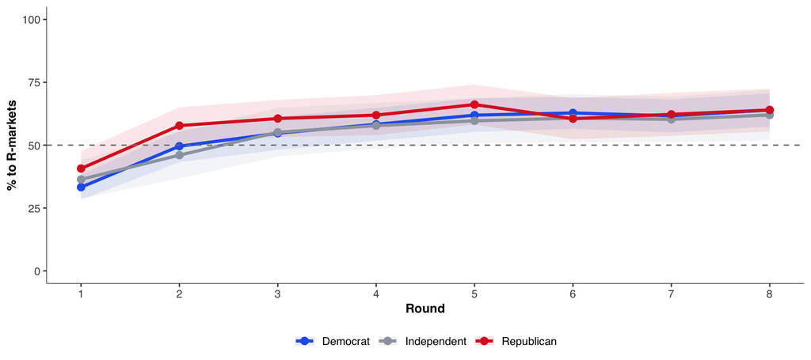

Figure 6: % allocated to R-leaning markets across rounds by party (pooled across versions)

```r
rounds |>
  filter(!is.na(party_lean)) |>
  group_by(party_lean, round) |>
  summarize(
    mean_pct_R = mean(pct_R, na.rm = TRUE),
    se = sd(pct_R, na.rm = TRUE) / sqrt(n()),
    .groups = "drop"
  ) |>
  ggplot(aes(x = round, y = mean_pct_R, color = party_lean)) +
  geom_ribbon(aes(ymin = mean_pct_R - 1.96 * se, ymax = mean_pct_R + 1.96 * se,
                  fill = party_lean), alpha = 0.1, color = NA) +
  geom_line(linewidth = 1.2) +
  geom_point(size = 2.5) +
  geom_hline(yintercept = 50, linetype = "dashed", color = "grey50") +
  scale_color_manual(values = PARTY_LEAN_COLORS) +
  scale_fill_manual(values = PARTY_LEAN_COLORS) +
  scale_x_continuous(breaks = 1:8) +
  scale_y_continuous(limits = c(0, 100)) +
  labs(x = "Round", y = "% to R-markets", color = NULL, fill = NULL)
```

## Market-level allocation by party

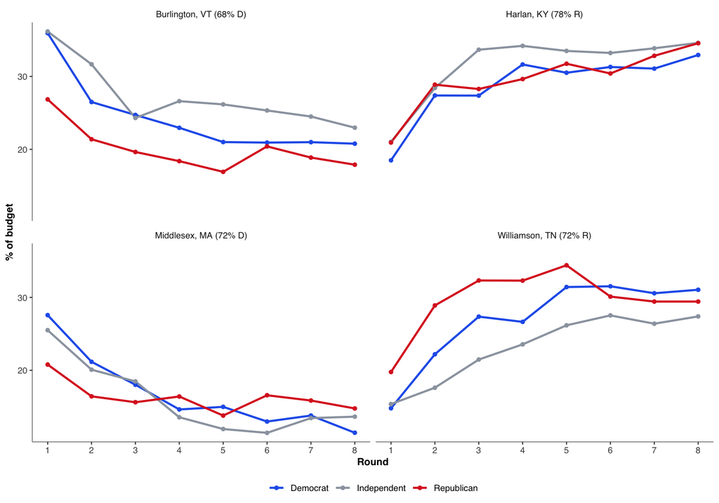

Figure 7: % of budget allocated to each market by party over 8 rounds

```r
rounds |>
  filter(!is.na(party_lean)) |>
  select(id, party_lean, round, alloc_harlan, alloc_williamson, alloc_burlington, alloc_middlesex) |>
  pivot_longer(cols = starts_with("alloc_"), names_prefix = "alloc_",
               names_to = "market", values_to = "allocation") |>
  mutate(pct_of_budget = allocation / 1000) |>  # $100k budget, so /1000 = %
  group_by(party_lean, round, market) |>
  summarize(mean_pct = mean(pct_of_budget, na.rm = TRUE),
            se = sd(pct_of_budget, na.rm = TRUE) / sqrt(n()),
            .groups = "drop") |>
  mutate(market_label = MARKET_LABELS[market]) |>
  ggplot(aes(x = round, y = mean_pct, color = party_lean)) +
  geom_line(linewidth = 1) +
  geom_point(size = 1.5) +
  facet_wrap(~market_label) +
  scale_color_manual(values = PARTY_LEAN_COLORS) +
  scale_x_continuous(breaks = 1:8) +
  labs(x = "Round", y = "% of budget", color = NULL)
```

## Mixed-effects model: learning rate × party

```r
tidy(lmm, effects = "fixed") |>
  mutate(
    term = str_replace_all(term, "difficulty", "version_"),
    term = str_replace_all(term, "version_medium", "Version B"),
    term = str_replace_all(term, "version_hard", "Version C"),
  ) |>
  mutate(across(where(is.numeric), \(x) round(x, 3))) |>
  knitr::kable(caption = "pct_R ~ round × party_lean + round × version + (1 + round | id)")
```

pct_R ~ round × party_lean + round × version + (1 + round | id)

| effect | term | estimate | std.error | statistic | df | p.value |
| --- | --- | --- | --- | --- | --- | --- |
| fixed | (Intercept) | 46.042 | 3.752 | 12.270 | 150.001 | 0.000 |
| fixed | round_c | 2.562 | 0.610 | 4.200 | 150.001 | 0.000 |
| fixed | party_leanIndependent | 0.757 | 4.652 | 0.163 | 150.001 | 0.871 |
| fixed | party_leanRepublican | 9.397 | 4.324 | 2.173 | 150.001 | 0.031 |
| fixed | Version B | -9.158 | 4.566 | -2.006 | 150.001 | 0.047 |
| fixed | Version C | -1.405 | 4.436 | -0.317 | 150.001 | 0.752 |
| fixed | round_c:party_leanIndependent | -0.382 | 0.756 | -0.505 | 150.001 | 0.614 |
| fixed | round_c:party_leanRepublican | -1.408 | 0.703 | -2.003 | 150.001 | 0.047 |
| fixed | round_c:Version B | 1.658 | 0.742 | 2.234 | 150.001 | 0.027 |
| fixed | round_c:Version C | 1.554 | 0.721 | 2.155 | 150.001 | 0.033 |

```r
lmm_anova_df <- lmm_anova |>
  as.data.frame() |>
  mutate(across(where(is.numeric), \(x) round(x, 3)))
rownames(lmm_anova_df) <- str_replace_all(rownames(lmm_anova_df), "difficulty", "version")

lmm_anova_df |> knitr::kable(caption = "Type III ANOVA for mixed-effects learning model")
```

Type III ANOVA for mixed-effects learning model

|  | Sum Sq | Mean Sq | NumDF | DenDF | F value | Pr(>F) |
| --- | --- | --- | --- | --- | --- | --- |
| round_c | 19752.326 | 19752.326 | 1 | 150.001 | 97.101 | 0.000 |
| party_lean | 1067.738 | 533.869 | 2 | 150.001 | 2.624 | 0.076 |
| version | 932.181 | 466.090 | 2 | 150.001 | 2.291 | 0.105 |
| round_c:party_lean | 832.523 | 416.262 | 2 | 150.001 | 2.046 | 0.133 |
| round_c:version | 1321.517 | 660.759 | 2 | 150.001 | 3.248 | 0.042 |

The mixed-effects model confirms: learning (round effect) is highly significant (*F* = 97.1, *p* < .001). Party affects starting allocation (Republicans start 9.4 pp higher, *p* = 0.076), but the round × party interaction is not significant (*p* = 0.13): all parties learn at the same rate.

## Pre-post measures by party

```r
party_alloc <- d |>
  filter(!is.na(party_lean)) |>
  group_by(party_lean) |>
  summarize(
    n = n(),
    mean_shift = mean(alloc_shift, na.rm = TRUE),
    sd_shift = sd(alloc_shift, na.rm = TRUE),
    t = t.test(alloc_shift)$statistic,
    p = t.test(alloc_shift)$p.value,
    d = mean(alloc_shift, na.rm = TRUE) / sd(alloc_shift, na.rm = TRUE),
    .groups = "drop"
  ) |>
  mutate(across(where(is.numeric), \(x) round(x, 3)))

party_alloc |> knitr::kable(caption = "Allocation shift by party lean")
```

Allocation shift by party lean

| party_lean | n | mean_shift | sd_shift | t | p | d |
| --- | --- | --- | --- | --- | --- | --- |
| Democrat | 67 | 20.582 | 23.575 | 7.146 | 0.000 | 0.873 |
| Independent | 36 | 18.333 | 24.417 | 4.505 | 0.000 | 0.751 |
| Republican | 47 | 11.489 | 28.620 | 2.752 | 0.008 | 0.401 |

```r
party_gap <- d |>
  filter(!is.na(party_lean)) |>
  group_by(party_lean) |>
  summarize(
    n = n(),
    mean_gap_change = mean(gap_change, na.rm = TRUE),
    t = t.test(gap_change)$statistic,
    p = t.test(gap_change)$p.value,
    d = mean(gap_change, na.rm = TRUE) / sd(gap_change, na.rm = TRUE),
    .groups = "drop"
  ) |>
  mutate(across(where(is.numeric), \(x) round(x, 3)))

party_gap |> knitr::kable(caption = "Belief gap change by party lean")
```

Belief gap change by party lean

| party_lean | n | mean_gap_change | t | p | d |
| --- | --- | --- | --- | --- | --- |
| Democrat | 67 | -24.687 | -6.173 | 0.000 | -0.754 |
| Independent | 36 | -23.694 | -3.663 | 0.001 | -0.611 |
| Republican | 47 | -17.426 | -3.358 | 0.002 | -0.490 |

## Starting bias predicts learning

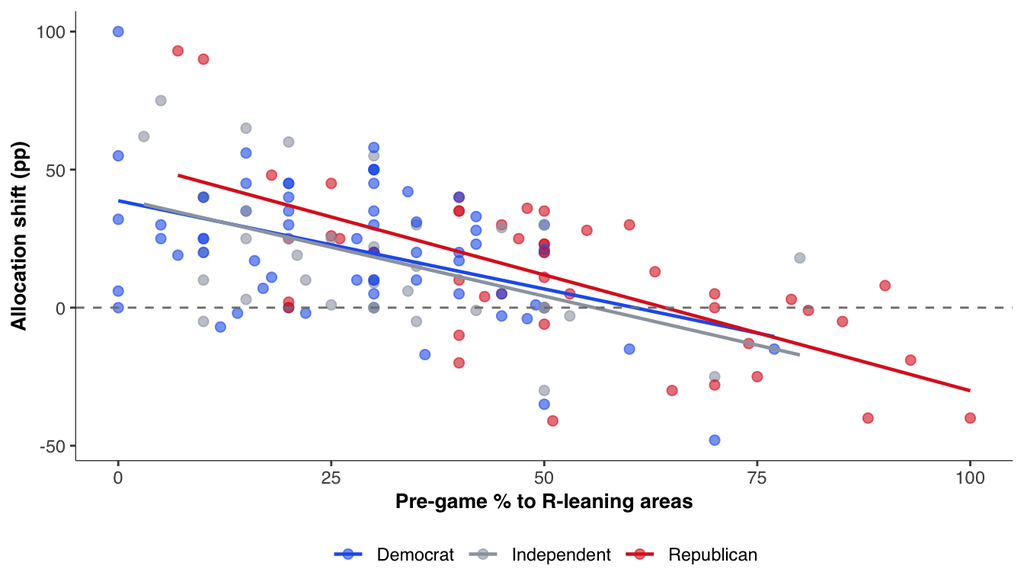

Figure 8: Participants who start more biased toward D-markets shift more

```r
d |>
  ggplot(aes(x = pre_pct_R, y = alloc_shift, color = party_lean)) +
  geom_point(alpha = 0.6, size = 2) +
  geom_smooth(method = "lm", se = FALSE, linewidth = 0.8) +
  geom_hline(yintercept = 0, linetype = "dashed", color = "grey50") +
  scale_color_manual(values = PARTY_LEAN_COLORS) +
  labs(x = "Pre-game % to R-leaning areas",
       y = "Allocation shift (pp)", color = NULL)
```

Pre-game R-allocation was negatively correlated with shift (*r* = -0.56, *p* < .001): participants who started furthest from optimal showed the largest corrections — exactly what the Bayesian model predicts.

# The “Difficulty” Manipulation Was Confounded

The three game versions were intended to vary difficulty (noise level), but the implementation simultaneously changed three parameters:

```r
tibble(
  Version = c("A (easy)", "B (medium)", "C (hard)"),
  `Half-max spend ($k)` = c(25, 30, 35),
  `Competition steepness (K)` = c(1.5, 2.0, 2.5),
  `Revenue noise (σ)` = c("20%", "30%", "35%"),
) |> knitr::kable(caption = "Game parameters by version — three things change at once")
```

Game parameters by version — three things change at once

| Version | Half-max spend ($k) | Competition steepness (K) | Revenue noise (σ) |
| --- | --- | --- | --- |
| A (easy) | 25 | 1.5 | 20% |
| B (medium) | 30 | 2.0 | 30% |
| C (hard) | 35 | 2.5 | 35% |

This is a problem. Higher $K$ penalizes high-competition D-markets disproportionately, making R-markets relatively *more* attractive in the “harder” versions:

```r
signal_ratio <- tibble(
  Version = c("A (easy)", "B (medium)", "C (hard)"),
  K = c(1.5, 2, 2.5),
  `Harlan multiplier` = round(exp(-K * 0.20), 3),
  `Middlesex multiplier` = round(exp(-K * 0.85), 3),
) |>
  mutate(`Harlan / Middlesex ratio` = round(`Harlan multiplier` / `Middlesex multiplier`, 1))

signal_ratio |> knitr::kable(caption = "Revenue multiplier: R-market advantage grows with K")
```

Revenue multiplier: R-market advantage grows with K

| Version | K | Harlan multiplier | Middlesex multiplier | Harlan / Middlesex ratio |
| --- | --- | --- | --- | --- |
| A (easy) | 1.5 | 0.741 | 0.279 | 2.7 |
| B (medium) | 2.0 | 0.670 | 0.183 | 3.7 |
| C (hard) | 2.5 | 0.607 | 0.119 | 5.1 |

In Version A, Harlan generates 2.7× the revenue per dollar vs. Middlesex. In Version C, this ratio grows to 5.1×. The “harder” version actually makes it *easier* to learn which markets are better — the amplified directional signal offsets the added noise.

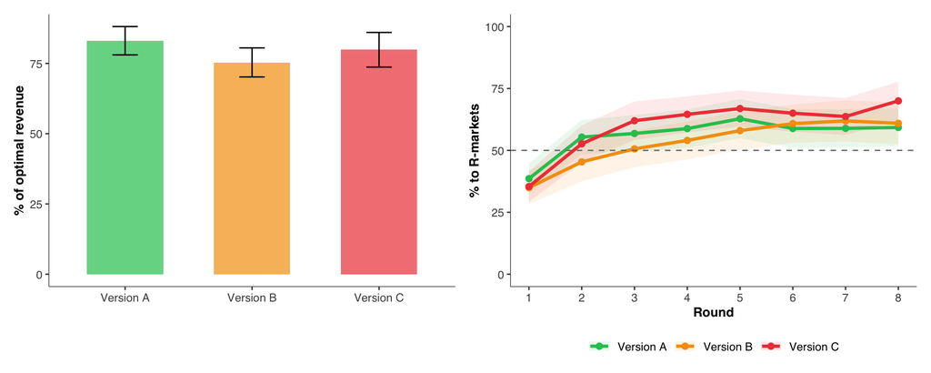

```r
# Compute per-version optimal revenue using the game's greedy algorithm parameters
# Optimal is version-specific since K and halfMax differ
p_opt <- d |>
  group_by(version) |>
  summarize(
    mean_pct_optimal = mean(game_pct_optimal, na.rm = TRUE),
    se = sd(game_pct_optimal, na.rm = TRUE) / sqrt(n()),
    .groups = "drop"
  ) |>
  ggplot(aes(x = version, y = mean_pct_optimal, fill = version)) +
  geom_col(alpha = 0.7, width = 0.6) +
  geom_errorbar(aes(ymin = mean_pct_optimal - 1.96 * se,
                    ymax = mean_pct_optimal + 1.96 * se), width = 0.2) +
  scale_fill_manual(values = setNames(VERSION_COLORS, VERSION_LABELS), guide = "none") +
  labs(x = NULL, y = "% of optimal revenue")

p_learn <- rounds |>
  group_by(version, round) |>
  summarize(mean_pct_R = mean(pct_R, na.rm = TRUE),
            se = sd(pct_R, na.rm = TRUE) / sqrt(n()), .groups = "drop") |>
  ggplot(aes(x = round, y = mean_pct_R, color = version)) +
  geom_ribbon(aes(ymin = mean_pct_R - 1.96 * se, ymax = mean_pct_R + 1.96 * se,
                  fill = version), alpha = 0.1, color = NA) +
  geom_line(linewidth = 1.2) + geom_point(size = 2) +
  geom_hline(yintercept = 50, linetype = "dashed", color = "grey50") +
  scale_color_manual(values = setNames(VERSION_COLORS, VERSION_LABELS)) +
  scale_fill_manual(values = setNames(VERSION_COLORS, VERSION_LABELS)) +
  scale_x_continuous(breaks = 1:8) +
  scale_y_continuous(limits = c(0, 100)) +
  labs(x = "Round", y = "% to R-markets", color = NULL, fill = NULL)

p_opt + p_learn
```

**Recommendation for the main study:** to create a clean difficulty manipulation, vary *only* the noise parameter ($\sigma$) while holding $K$ and half-max constant. This isolates signal-to-noise ratio as the sole dimension of difficulty, which is what the Bayesian learning model’s $\tau$ parameter directly captures.

# Experience Measures

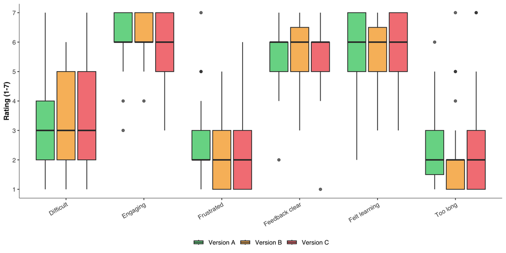

Figure 10: Experience ratings by version (1 = Strongly disagree, 7 = Strongly agree)

```r
exp_labels <- c(
  exp_difficult = "Difficult",
  exp_engaging = "Engaging",
  exp_frustrated = "Frustrated",
  exp_feedback_clear = "Feedback clear",
  exp_learning = "Felt learning",
  exp_too_long = "Too long"
)

d |>
  select(id, version, all_of(names(exp_labels))) |>
  pivot_longer(cols = all_of(names(exp_labels)), names_to = "item", values_to = "rating") |>
  mutate(item_label = exp_labels[item],
         item_label = factor(item_label, levels = exp_labels)) |>
  ggplot(aes(x = item_label, y = rating, fill = version)) +
  geom_boxplot(alpha = 0.7, width = 0.7, position = position_dodge(0.8)) +
  scale_fill_manual(values = setNames(VERSION_COLORS, VERSION_LABELS)) +
  scale_y_continuous(breaks = 1:7, limits = c(1, 7)) +
  labs(x = NULL, y = "Rating (1-7)", fill = NULL) +
  theme(axis.text.x = element_text(angle = 30, hjust = 1))
```

```r
scorecard <- d |>
  group_by(version) |>
  summarize(
    n = n(),
    `Alloc shift (pp)` = mean(alloc_shift, na.rm = TRUE),
    `Alloc shift d` = mean(alloc_shift, na.rm = TRUE) / sd(alloc_shift, na.rm = TRUE),
    `% of optimal rev` = mean(game_pct_optimal, na.rm = TRUE),
    Engaging = mean(exp_engaging, na.rm = TRUE),
    Frustrated = mean(exp_frustrated, na.rm = TRUE),
    `Felt learning` = mean(exp_learning, na.rm = TRUE),
    .groups = "drop"
  ) |>
  mutate(across(where(is.numeric), \(x) round(x, 2)))

scorecard |> knitr::kable(caption = "Version calibration scorecard")
```

Version calibration scorecard

| version | n | Alloc shift (pp) | Alloc shift d | % of optimal rev | Engaging | Frustrated | Felt learning |
| --- | --- | --- | --- | --- | --- | --- | --- |
| Version A | 51 | 16.84 | 0.77 | 83.08 | 6.08 | 2.37 | 5.69 |
| Version B | 47 | 15.28 | 0.54 | 75.36 | 6.17 | 2.19 | 5.83 |
| Version C | 52 | 19.27 | 0.72 | 79.87 | 5.90 | 2.38 | 5.90 |

All three versions score comparably on engagement and felt learning. For the main experiment, any version works — the priority is fixing the confounded difficulty manipulation.

# Methods

## Sample

```r
sample_tab <- d |>
  group_by(version) |>
  summarize(
    n = n(),
    `Mean age` = mean(age, na.rm = TRUE),
    `% Female` = 100 * mean(gender == "Female", na.rm = TRUE),
    `Median duration (min)` = median(duration_min, na.rm = TRUE),
    .groups = "drop"
  ) |>
  mutate(across(where(is.numeric), \(x) round(x, 1)))

sample_tab |> knitr::kable(caption = "Sample by version")
```

Sample by version

| version | n | Mean age | % Female | Median duration (min) |
| --- | --- | --- | --- | --- |
| Version A | 51 | 40.7 | 37.3 | 9.8 |
| Version B | 47 | 43.1 | 38.3 | 8.6 |
| Version C | 52 | 39.9 | 42.3 | 8.1 |

We recruited 150 participants from Prolific, randomly assigned to Version A (n = 51), B (n = 47), or C (n = 52).

```r
d |>
  count(version, party) |>
  pivot_wider(names_from = version, values_from = n, values_fill = 0) |>
  knitr::kable(caption = "Party affiliation by version")
```

Party affiliation by version

| party | Version A | Version B | Version C |
| --- | --- | --- | --- |
| Independent | 13 | 11 | 12 |
| Lean Democrat | 11 | 8 | 14 |
| Lean Republican | 14 | 11 | 8 |
| Strong Democrat | 12 | 9 | 13 |
| Strong Republican | 1 | 8 | 5 |

Collapsed: 67 Democrats, 36 Independents, 47 Republicans.

## Game design

Participants played 8 rounds of a marketing allocation game. Each round, they distributed a $100,000 budget across four U.S. markets varying in partisan lean and competitive intensity. After each round, participants saw their revenue by market and cumulative earnings. The optimal strategy is to concentrate spending in R-leaning markets where low competition means higher returns per dollar — even though D-leaning markets have slightly higher eco-product receptivity (75% vs 65%).

Three game versions varied noise level, competition penalty steepness ($K$), and half-max spending threshold simultaneously. As documented above, this confounded the intended difficulty manipulation: higher $K$ amplified the relative R-market signal, offsetting the added noise.

## Measures

- **Pre/post beliefs**: “What % of Democrats/Republicans would buy eco-friendly home products?” (0-100 slider)
- **Pre/post allocation**: “If you had $100k to market eco-friendly products, what % would you spend in Republican-leaning areas?” (0-100 slider)
- **Experience**: 6 items on a 7-point Likert scale (difficult, engaging, frustrated, feedback clear, felt learning, too long)
- **Demographics**: Age, gender, party affiliation (5-point), education

## Statistical approach

1. **Pre-post effects**: Within-subject one-sample *t*-tests on allocation shift and belief gap change, with Cohen’s *d* as effect size.
2. **Learning curves**: Linear mixed-effects model with random intercepts and slopes per participant: `pct_R ~ round × party_lean + round × version + (1 + round | id)`.
3. **Bayesian learning model**: Non-linear least squares fit of $\text{pct\_R}_t = \theta^* + (m_0 - \theta^*) \cdot \tau / (\tau + t)$ to group-level means by party, following the Normal-Normal updating framework (DeGroot, 1970; Erdem & Keane, 1996).